# How Gender and Immigrant Background Affect Student Standing

## by Marc Angelo Acebedo

## Investigation Overview

> For the PISA 2012 dataset, I wanted to see how **environment** and **background** variables factor into *student drive* and *academic performance*.

## Dataset Overview

> The data consists of around 460,000 students from 65 countries. I isolate my focus on the above listed 4 attributes, and the resulting dataset went down from over 600 columns to only 14. Many columns were dropped due to irrelevance in my investigation purposes. Here is a breakdown of each variable group:

### CAUSES

- **Environment**: Teacher helpfulness, sense of belonging, acculturation
- **Background**: Country, gender, parent occupational background, mother immigrant background

### EFFECTS

- **Student Drive**: Work ethic, future optimism, self esteem
- **Academic Performance**: Math, Reading, and Science Scores

> Though my focus could have taken many different paths, I chose the following two approaches for my key insights.

# Approach 1. Immigrant Background by Drive and Academic Performance

## Distribution of Students with Immigrant Mothers

Of all the students who answered the Mother Immigrant question, the overwhelming majority of students answered "Yes" at 77.83%. The difference is so staggering that the difference in proportions is 55.66% in favor of students with immigrant backgrounds.

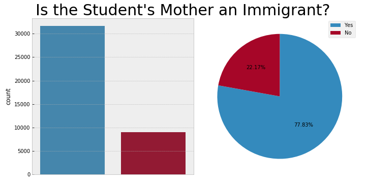

```python
Image(filename = './visuals/univariate/mother-immigrant.png')
```

## Mother Immigrant Background by Student Drive Factors

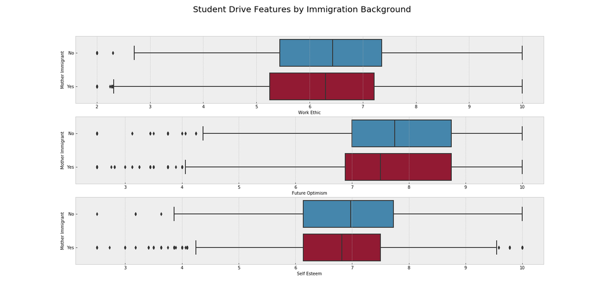

```python
Image(filename = './visuals/bivariate/drive-m-immigrant.png')
```

**Observation 1:** Students who do not come from an immigrant background tend to score higher on all student drive variables than those who do. This is intuitive enough, as I would assume non-immigrants are much more familiar with their country of citizenship, and thus would adapt better.

**Observation 2:** Again, future optimism scores higher on average for all student drive variables in comparison to work ethic and self esteem.

## Immigrant Background by Academic Performance (Scores)

*There is a vast disparity in records for students whose mothers aren't or are immigrants. Therefore, we cannot rely on the following histograms for sole counts.*

As it was previously established, students from immigrant backgrounds score lower for work ethic, future optimism, and self-esteem. However, *they score consistently higher than students not from an immigrant background.*

This is a key takeaway: *students with immigrant mothers tend to have a lower student drive and a more pessimistic views of themselves, but consistently outperform non-immigrant students by a large margin.*

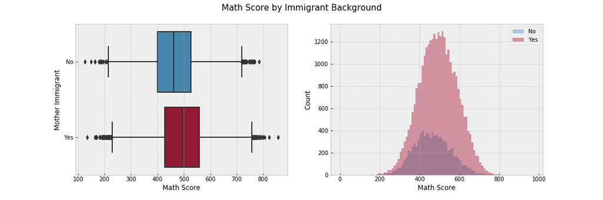

```python
Image(filename = './visuals/bivariate/immigrant-math.png')
```

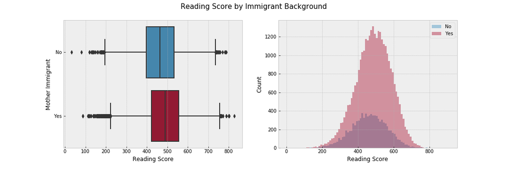

```python
Image(filename = './visuals/bivariate/immigrant-reading.png')
```

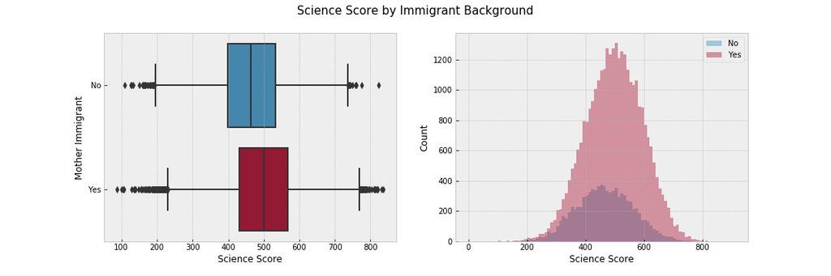

```python
Image(filename = './visuals/bivariate/immigrant-science.png')
```

# Approach 2. Gender by Student Drive and Academic Performance

## Distribution of Male and Female Students

Gender is about **evenly split** with female students at 50.5% and males at 49.5%, so we can safely say that conclusions drawn by gender are fair and representative.

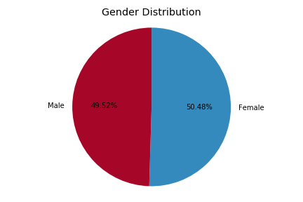

```python
Image(filename = './visuals/univariate/gender-count.png')
```

## Gender by Student Drive Features

Girls tend to have a *higher work ethic but significantly less self-esteem* than boys. Meanwhile, there is no gender gap for future optimism.

This is a key takeaway as this discovery reflects the reality that girls are often discouraged and intimidated in academic settings, despite putting more in more effort on average.

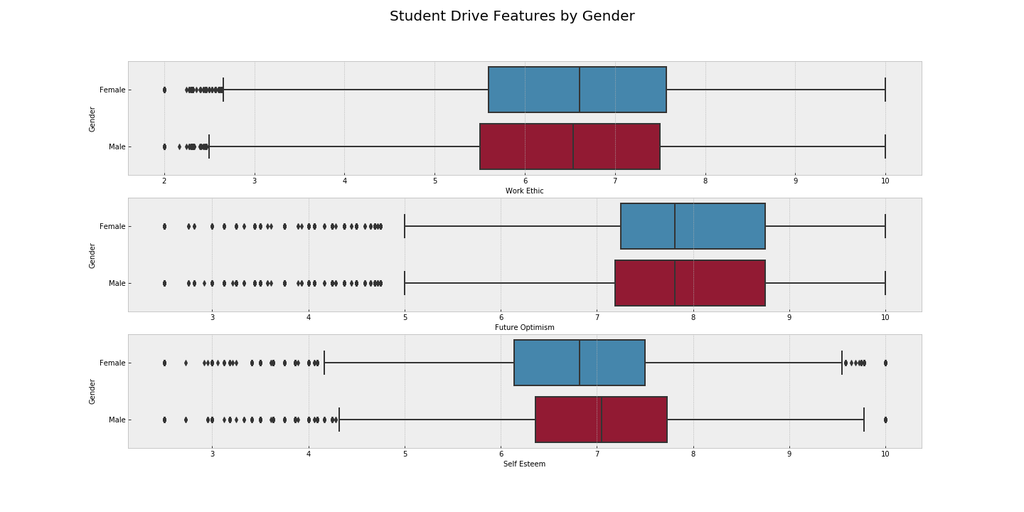

```python
Image(filename = './visuals/bivariate/drive-gender.png')
```

## Gender by Academic Performance (Scores)

The count by gender is evenly split, so we can draw reliable conclusions from the following histograms.

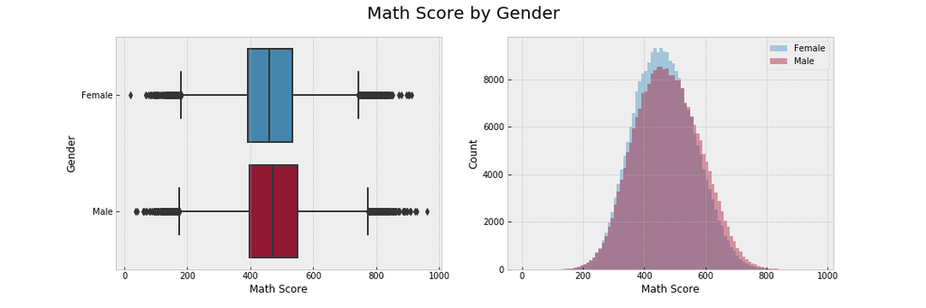

```python
Image(filename = './visuals/bivariate/math-score-gender.png')
```

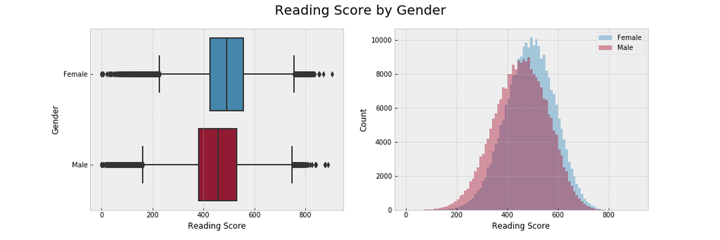

```python
Image(filename = './visuals/bivariate/reading-score-gender.png')
```

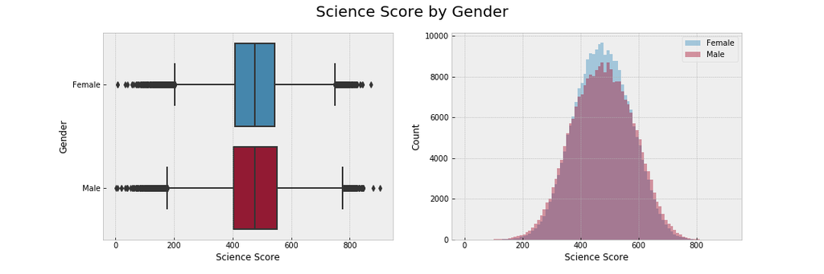

```python
Image(filename = './visuals/bivariate/science-score-gender.png')
```

*The patterns in the histograms correlating score and gender show more girls scoring the average score per subject than boys.*

**Observation 1:** The only truly notable difference in the gender gap is under *reading score, where girls outperform boys on average*, as indicated by the box plots.

**Observation 2:** Under math and science scores, more girls than boys scored around 500.

**Observation 3:** Under reading scores, more boys than girls score between 0 - 500, but more girls than boys score between 500 - 800.

### Is this outperformance in reading scores due to girls' higher work ethic? What about the other scores? Let's look deeper.

## Gender by Academic Performance and Work Ethic

### Despite girls having an overall higher work ethic, if a boy and girl had the same work ethic score, *the boy is most certainly guaranteed to score higher for math.* However, the *contrary is true for reading scores.*

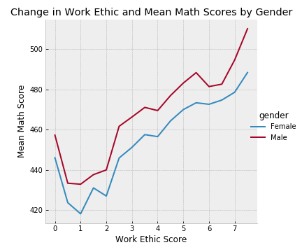

```python
Image('./visuals/multivariate/work-ethic-math-gender.png')
```

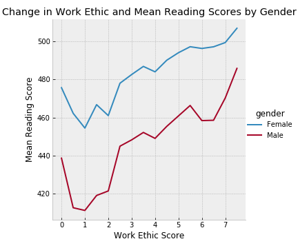

```python
Image('./visuals/multivariate/work-ethic-reading-gender.png')
```

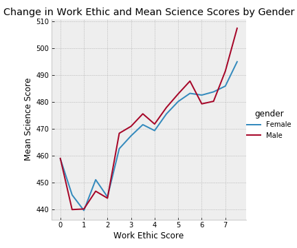

```python
Image('./visuals/multivariate/work-ethic-science-gender.png')
```

**Observation 1:** The higher the student's work ethic, boys *always* outperform girls for mean math scores.

**Observation 2:** The higher the student's work ethic, girls *always* outperform boys for mean reading scores.

**Observation 3:** There are many overlaps between science scores between boys and girls, so it is hard to draw a trend conclusion. We can only say that the mean science score vs. work ethic depicts an overall positive trend for both genders.